# Bikeshare perdict

Jiahang Li

2024-04-27

# 1 Overview

Bike-sharing systems are a sustainable and flexible transportation solution that allows people to borrow bicycles from designated stations throughout a city. One of the important challenges facing bike-sharing systems is to ensure bikes are available when and where they are needed. This situation raises awareness of how to efficiently redistribute bicycles in a certain time period across different stations to meet diverse demands at different times and locations, which is also known as rebalancing.

Re-balancing aims to prevent docks from being either completely full or empty, thus maintaining operational efficiency and user satisfaction. The bike-sharing system would perform more effectively when high-demand stations are filled with bikes to meet user needs, while low-demand stations maintain a suitable number of bikes to ensure availability. The process requires precise anticipation and prediction of bike share demand to relocate bikes.

This exercise aims to enhance rebalancing using predictive machine learning models and Ordinary Least Square (OLS) regression that can forecast short-term demand based on spatial patterns and time lag effects in Jersey City. Moreover, discounts or rewards can be offered to users to encourage them to return bikes to docks that are likely to be empty or to rent from docks that are near capacity. Since the model is time-space dependent, historical data, weather data, and lag-effect variables will be considered and blended into the model.

The dataset utilized in this analysis is sourced from NYC OpenData and contains comprehensive records of Citi Bike usage, updated monthly. While Jersey City is situated in New Jersey, Citi Bike’s operations are primarily centered in New York City, which manages and releases the dataset. The temporal scope of our study focuses on the period from March 1, 2024, to April 1, 2024, exclusively examining bikeshare data within Jersey City. This dataset principally comprises the locations and names of the stations where users initiate and conclude their journeys. Additionally, to enrich our spatial analysis, we procured the census tract geometries for all of Hudson County, including Jersey City, using the tidycensus package.

Our current bikeshare dataset, while including spatial attributes such as latitude and longitude, isn’t inherently spatial. To rectify this, we plan to spatially enable the dataset by associating each ride’s starting location with the corresponding census tract geometry. Our focus is on the origins of rides, as we aim to predict station capacity based on the demand for bikes. Essential to this process is the exclusion of records lacking precise latitude and longitude data. Additionally, we’ve identified and will need to discard entries with incorrect geocodes.

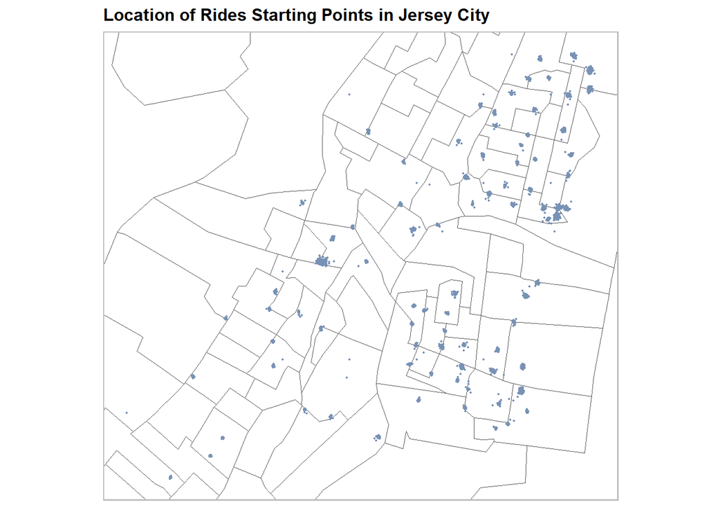

we created line strings that connect between the start and end locations of each ride. For the simplicity of visualization, we only visualize 200 rides. We can see that most of the rides occur within Jersey City,

[interactive chart not shown]

# 2 Exploratory Analysis

In this section, we perform some further exploratory analysis of our data set.

## 2.1 Temporal Analysis

Based on the chart, it appears that there is a distinct pattern in the usage of bike share trips in Jersey City throughout March 2024. The data suggests regular fluctuations that likely correspond to daily cycles of peak and off-peak usage hours. It suggests increased bike share usage during weekdays, consistent with rush hours, and a noticeable drop during the weekends. This indicates that the bike share system is heavily utilized for commuting purposes during the work week, with reduced usage on weekends, possibly when people are less likely to follow work-related routines. This temporal pattern is typical for urban bike share programs, reflecting the ebb and flow of a city’s daily life and weekly cycle.

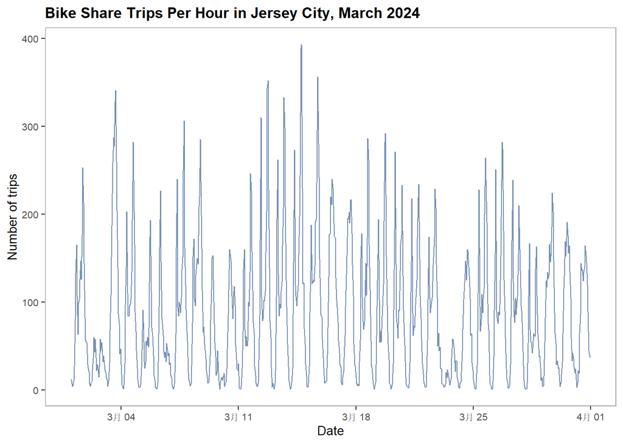

When visualizing the distribution of bike share trips by station for each hour in March, there’s a significant skew towards the lower end of the trip count spectrum. This means that a large number of the bike share stations have very few trips (close to zero), while a small number of stations have a high frequency of usage, with the maximum observed being 30 rides in an hour for a specific station on a given day.

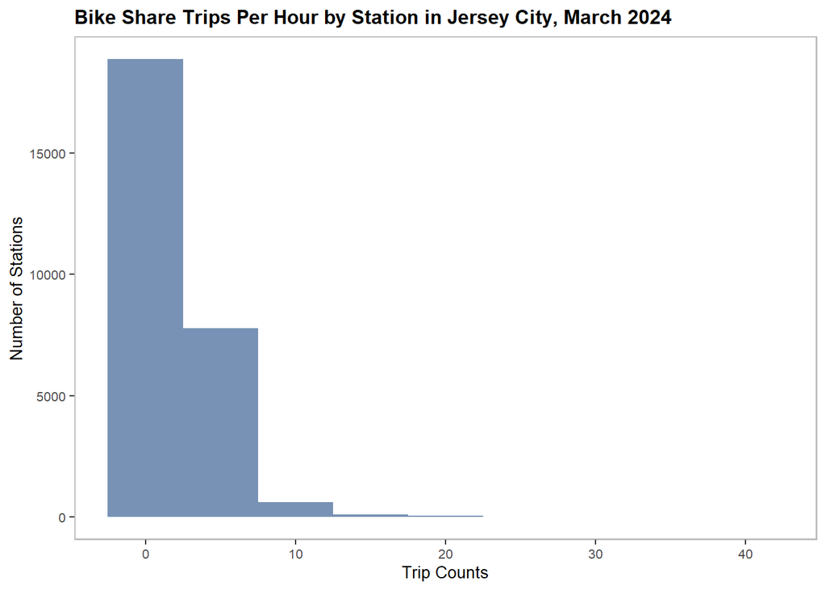

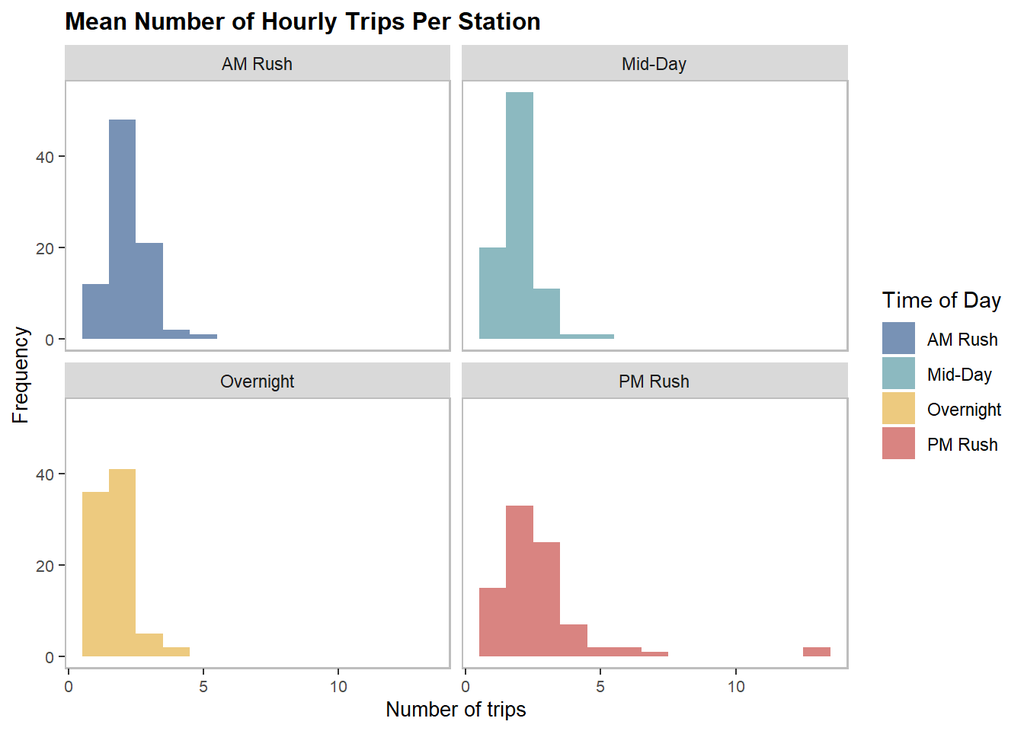

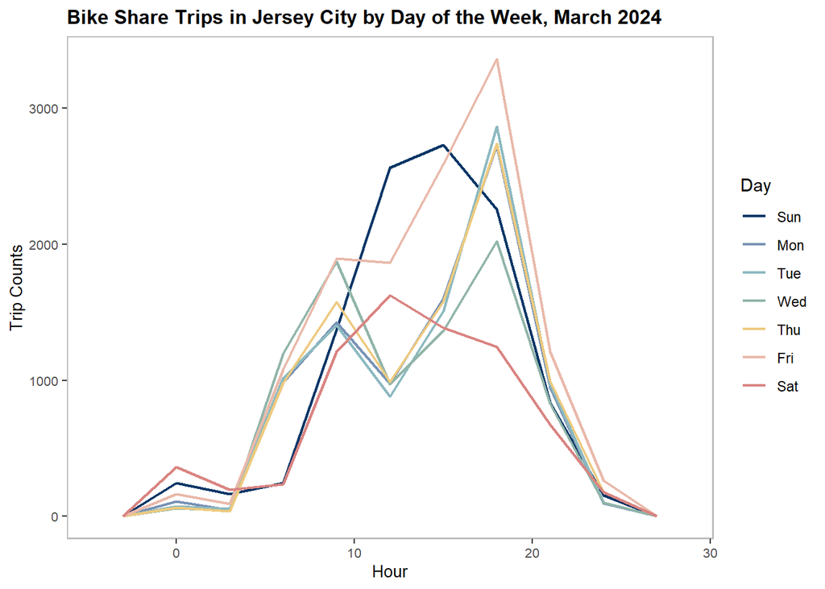

The graph compares the total bike share trips in Jersey City during weekdays and weekends in March 2024. The weekday line (blue) shows a bi-modal distribution, with two significant peaks that suggest high trip counts during typical morning and evening rush hours, indicating a strong use for commuting. The weekend line (red) presents a more bell-shaped curve with a single, broad peak that peaks lower than the highest weekday peak. This likely indicates a more leisurely use of bikes, with trips spread out across the day rather than concentrated around rush hours. Overall, bike share usage is significantly higher on weekdays compared to weekends, underscoring its role in supporting the daily work commute. The dramatic difference between the shapes of the two lines emphasizes the change in travel patterns between the workweek and the weekend.

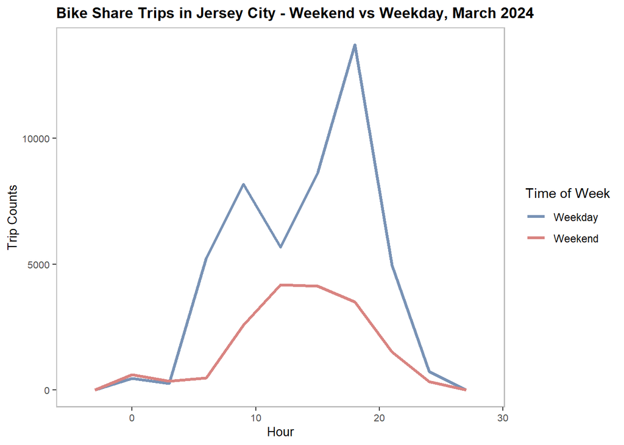

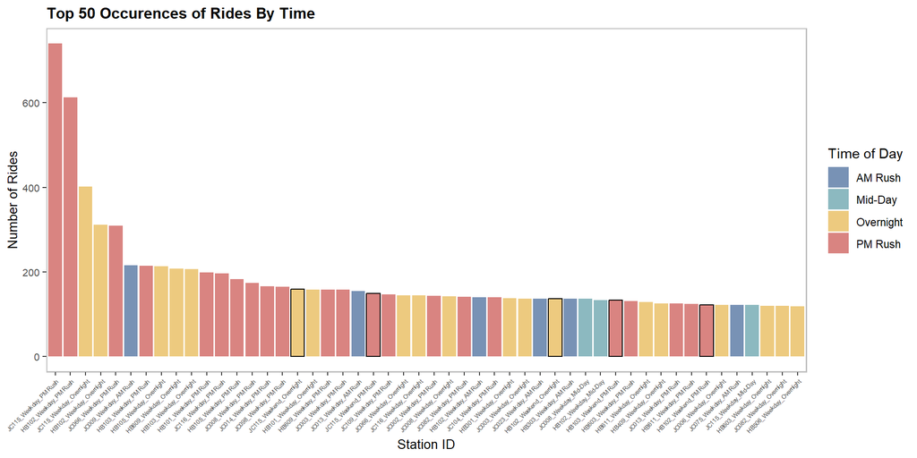

## 2.2 Spatial Analysis

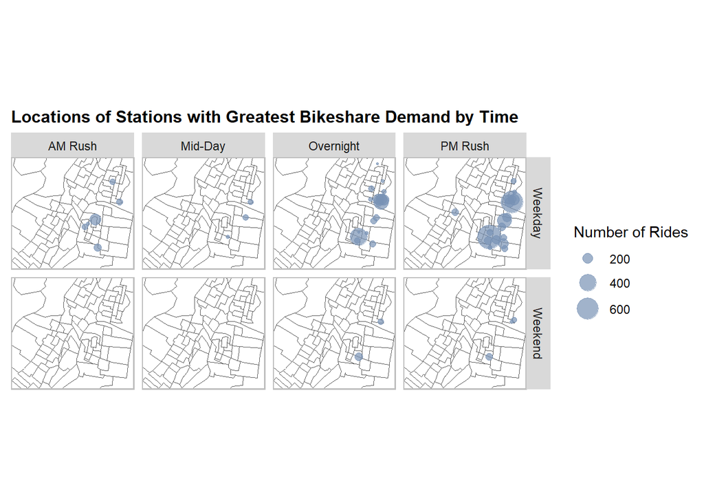

[figure not shown]

The map illustrates a distinct pattern of clustering among bike share stations with higher demand. Specifically, it reveals two prominent clusters where a select few stations experience an especially high volume of rides. These central nodes of activity are encircled by stations with moderately fewer rides, indicating a gradient of demand within each cluster.

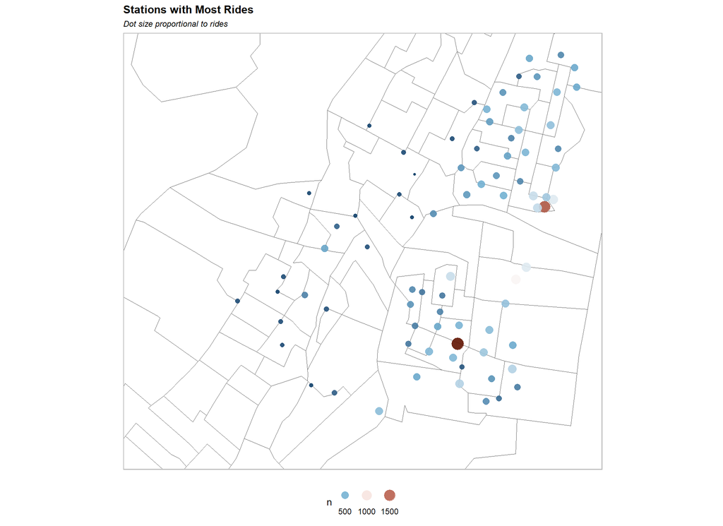

## 2.3 Weather Analysis

Considering the influence of meteorological conditions on bikeshare demand, we postulate that inclement weather, such as rain, strong winds, or extreme heat, typically leads to a decline in usage. To validate this, we acquired hourly weather data from Newark Airport for the period spanning March 1, 2024, to April 1, 2024, using the riem_measures function, which is representative of weather patterns for the entirety of Jersey City. A summary panel, termed the weather.Panel, was created to encapsulate key weather variables — temperature, precipitation, and wind speed — on an hourly basis.

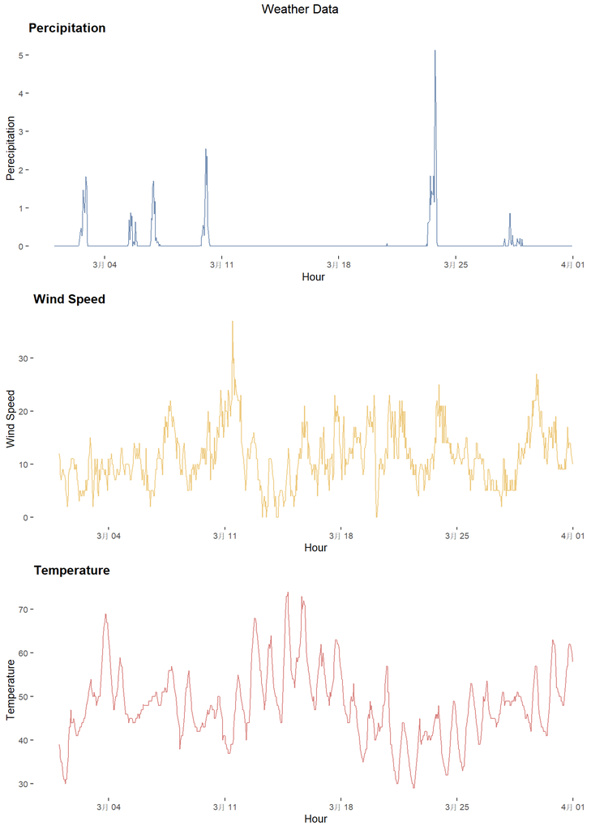

# 3 Space-Time Panel

In the following steps, we created a study panel where each instance in the panel is a unique combination of space and time. In other words, each row will represent the ride at a particular station during a particular hour.

## 3.1 Weather Correlation

The red trend lines across the panels indicate that as temperature rises, the mean trip count tends to increase as well, suggesting a positive correlation between warmer temperatures and the use of bikeshare services. This pattern is consistent across all the weeks presented, although the density of points and the slope of the trend lines suggest that the strength of this relationship might vary from week to week.

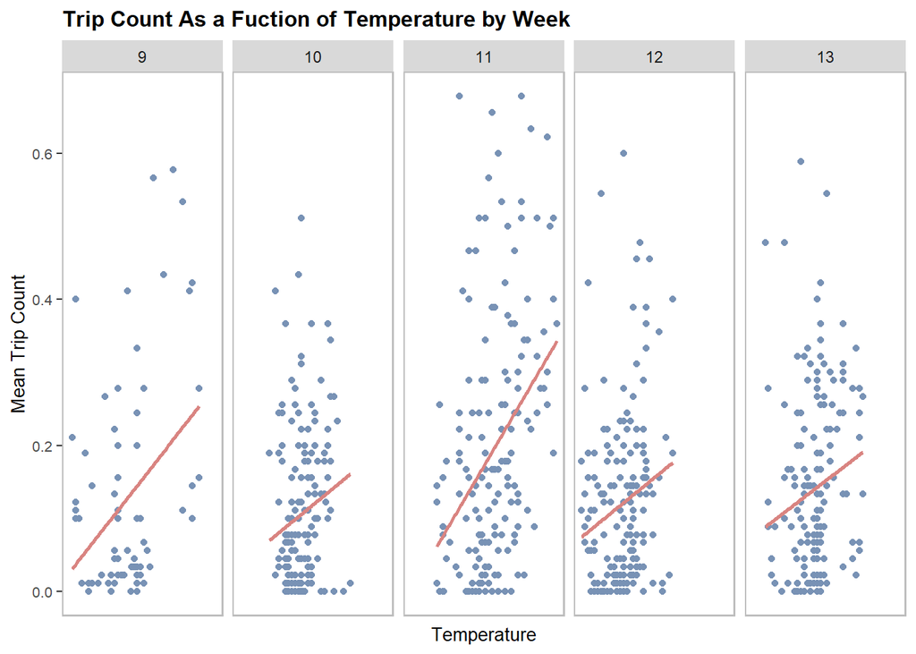

The red trend lines superimposed on the scatter plots suggest an overall relationship between wind speed and bikeshare usage. However, unlike the previous chart with temperature, the relationship here does not seem as straightforward or consistent across the weeks.

For some weeks, the trend line appears to show a slight positive correlation, implying that trip counts increase with wind speed up to a certain point. This could be non-intuitive as higher wind speeds might typically deter outdoor activities like biking. For other weeks, the trend line is almost horizontal, suggesting little to no correlation between wind speed and trip counts. This could indicate that wind speed has a less direct or more variable impact on bikeshare usage.

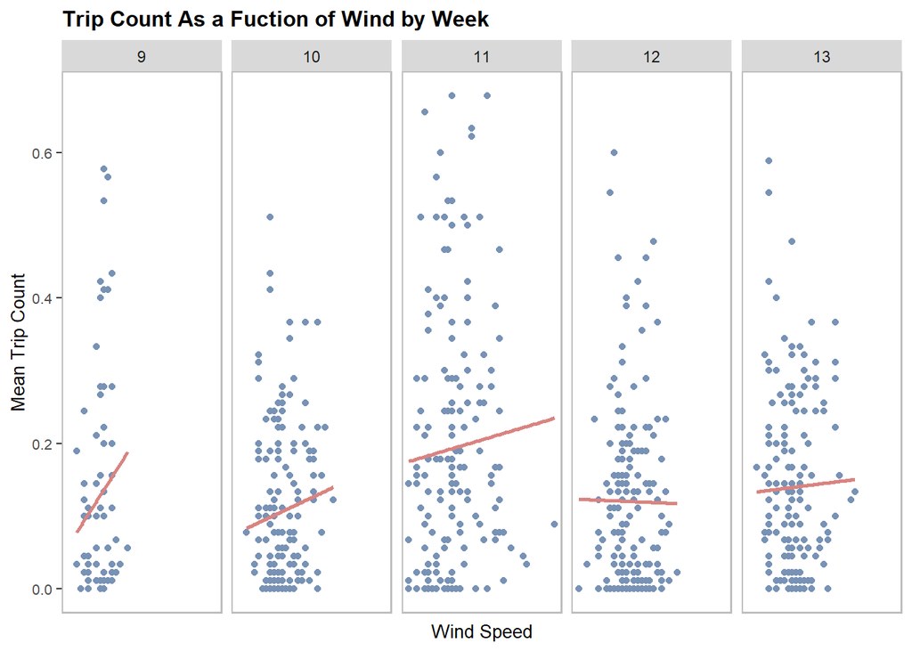

## 3.2 Serial Correlation

If there’s a temporal correlation in the number of bikeshare trips, incorporating time lag features could enhance the accuracy of predictive models. This is based on the premise that the volume of trips during a given hour is likely to be related to the volume in the hours just preceding or following it. Understanding trip patterns from one hour can thus inform us about trip patterns in adjacent hours. To harness this relationship, we’ve computed six distinct time lag variables to aid in our estimations.

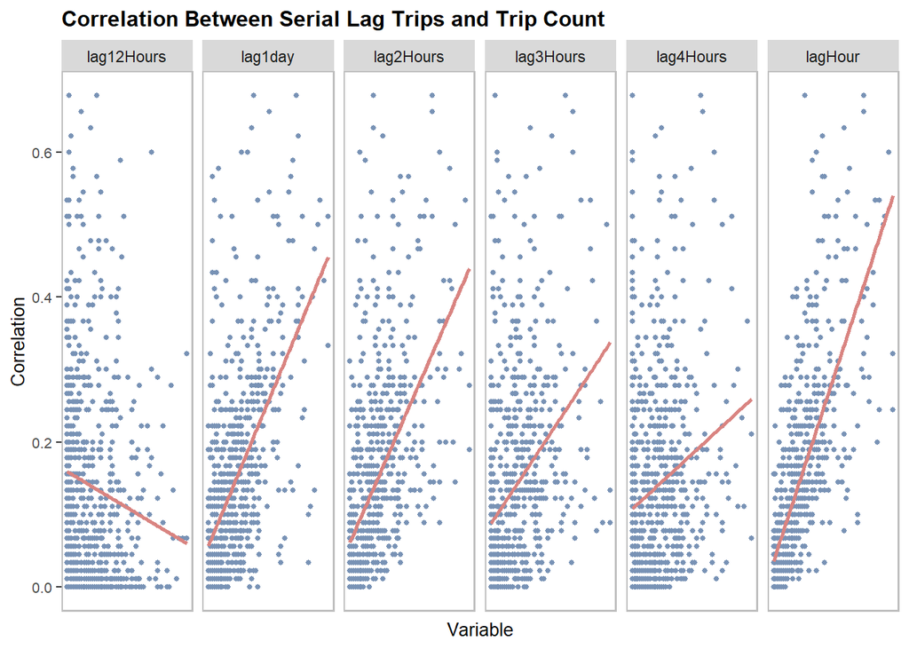

# 4 Spatial Correlation

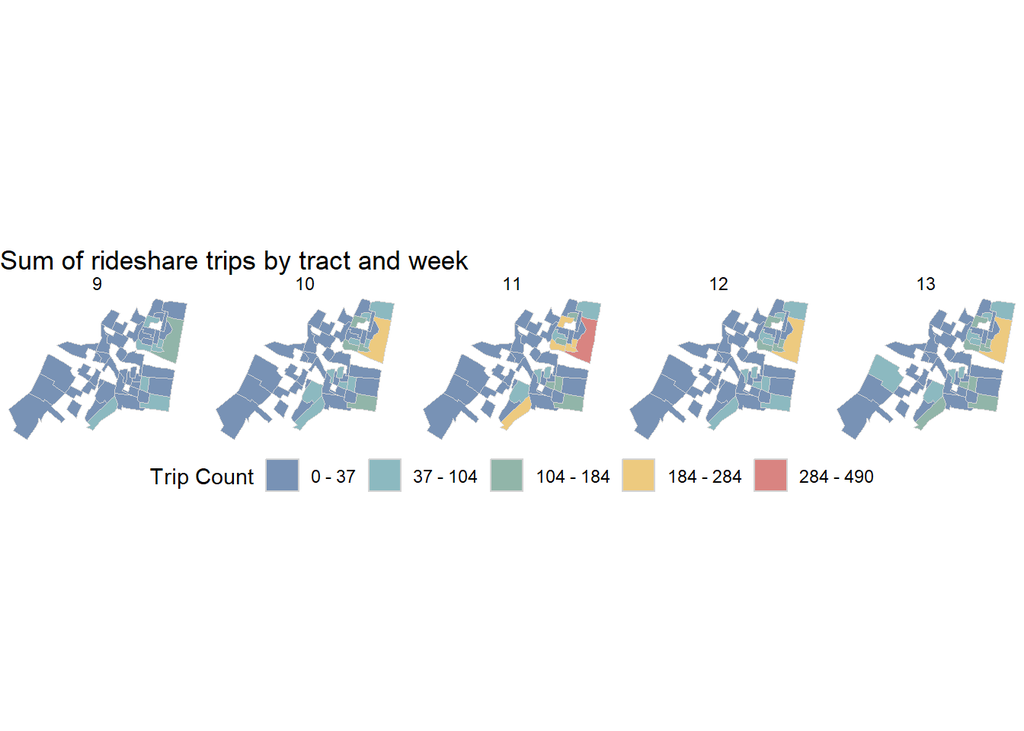

# 5 Regression Models

Four models are produced from the initial 3-2 week training-test split , with increasing complexity, from a just time based, just spatial based (fixed-effect), a time-spatial model to a time spatial with lagged features model. As can be observed in the following chart, the greatest improvement to the model is made by adding the lagged variables, given that things that happen in time (as well as in space) are more related to closer events than to farther events.

## 5.1 Predict for test data

A better notion of how much the fitness of the models improves is given by looking at ridership as a function of time for both the predicted and the actual ridership.

```
## # A tibble: 8 × 8
##    week data     Regression       Prediction Observed Absolute_Error   MAE sd_AE
##   <dbl> <list>   <chr>            <list>     <list>   <list>         <dbl> <dbl>
## 1     9 <tibble> ATime_FE         <dbl>      <dbl>    <dbl [6,480]>  0.246 0.588
## 2    10 <tibble> ATime_FE         <dbl>      <dbl>    <dbl [15,030]> 0.238 0.430
## 3     9 <tibble> BSpace_FE        <dbl>      <dbl>    <dbl [6,480]>  0.223 0.547
## 4    10 <tibble> BSpace_FE        <dbl>      <dbl>    <dbl [15,030]> 0.192 0.420
## 5     9 <tibble> CTime_Space_FE   <dbl>      <dbl>    <dbl [6,480]>  0.228 0.544
## 6    10 <tibble> CTime_Space_FE   <dbl>      <dbl>    <dbl [15,030]> 0.204 0.413
## 7     9 <tibble> DTime_Space_FE_… <dbl>      <dbl>    <dbl [6,480]>  0.185 0.503
## 8    10 <tibble> DTime_Space_FE_… <dbl>      <dbl>    <dbl [15,030]> 0.161 0.401
```

## 5.2 Examine Error Metrics for Accuracy

From the following two plots, we can find regression model 4 considering hour lags has the best goodness of fit. Model 4 is also not perfectly predicting may because of university spring break in March, while the time of spring break in unsure by institutions so unfortunately we didn’t involve holiday lag and holidays in the model. The relatively low ridership in general may also be another reason for the under prediction.

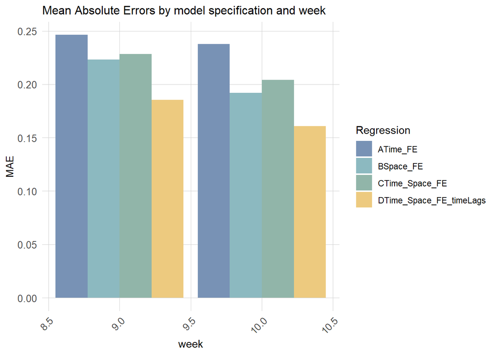

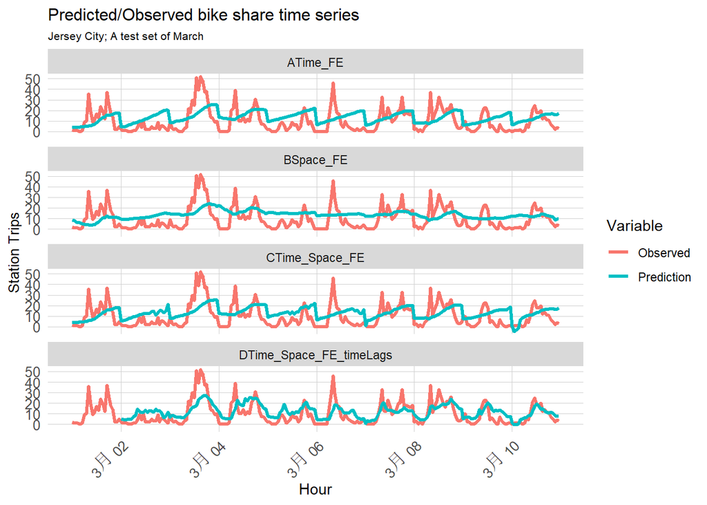

Then, we will continue examine spatial distribution of the MAE with model 4.

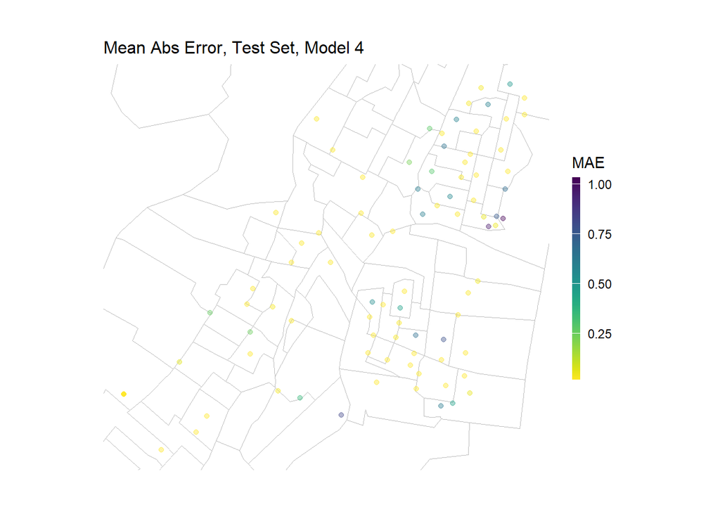

There is also no significant difference between the MAE in the two weeks (week 9 and week 10).

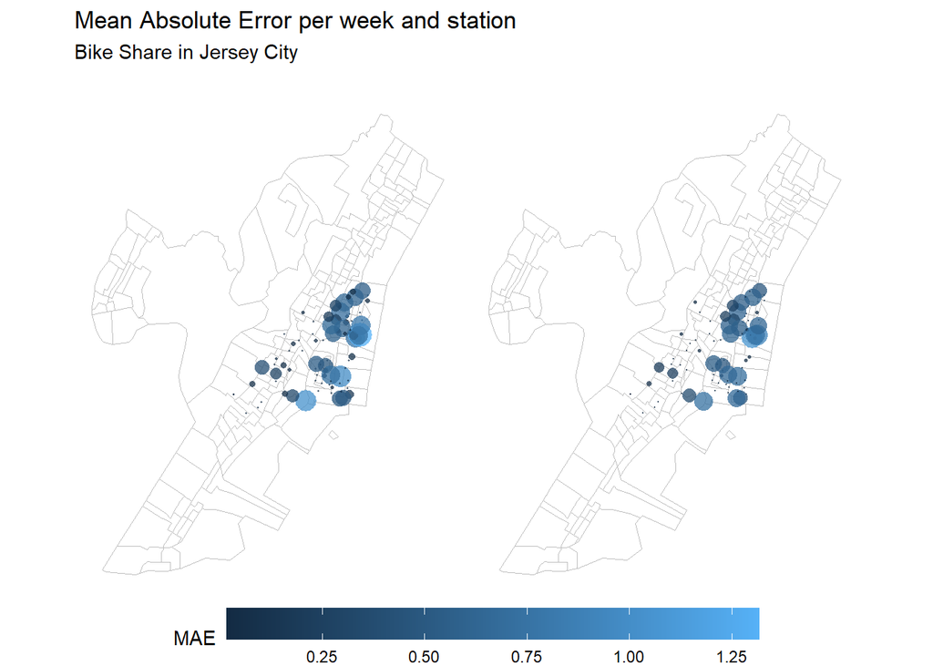

## Space-Time Error Evaluation

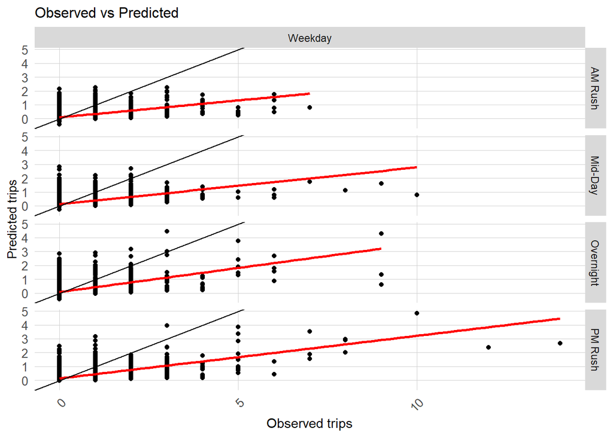

The scatter plots examine the relationship between socio-economic factors — median income, percentage using public transport, and percentage of white residents — and the predictive errors. There is a visible trend that as median income and percentage of white residents increase, so does the MAE, suggesting that these socio-economic factors may influence ridership patterns in ways that the model does not fully capture. The percentage of residents using public transportation shows less clear of a trend, indicating the need for further investigation into how public transportation usage correlates with bike-share ridership.

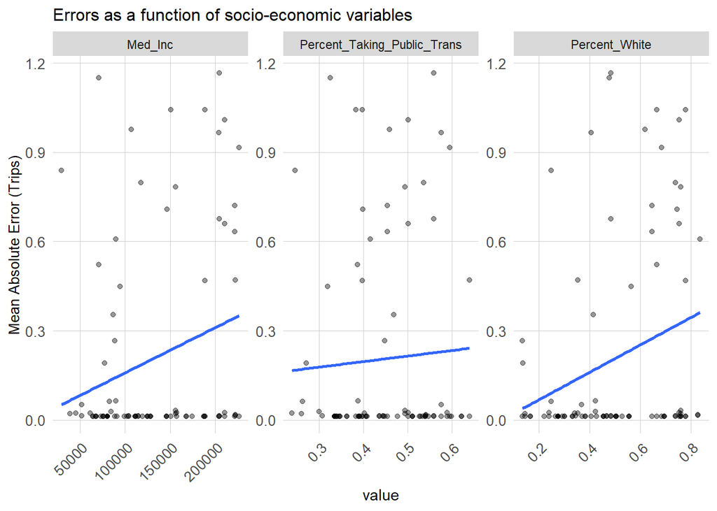

## 5.3 Cross-validation

Finally, a 100-fold cross validations are made on the whole March data, and get a final MAE of 0.177, which includes that even tho this model cant perfectly predict the result, but the error is not that significant. However, this small MAE is also due to the small ridership at each station.

| Mean Absolute Error | Standard Deviation of MAE |
| --- | --- |
| 0.1774857 | 0.0173185 |

# 6 Conclusion